# DINA – A story of a precedent Ethical dilemma for researchers

Judita Matyasova

01 marts, 2021

## Introduction

### What is this exercise about?

The main story is based on Dina Babbitt’s experience. She survived the concentration camp because she painted watercolours for the famous doctor Josef Mengele in Auschwitz. IN exchange for this, he promised her that she and her mother would remain alive. But who is the owner of these watercolours? And how is it that a personal artistic item became an important object in a museum?

### What's expected of you?

- Read Dina's story.
- Watch her testimony on the digital archives at United States Holocaust Memorial Museum.
- Watch the discussion of Dina and historian David Rappaport.
- Search for information about Dina on the online archive of American Congress.
- Think about the ethical dilemma of Dina’s situation.

## Her story

Dina and her mother survived the war. Dina moved to the USA, where she became famous as an illustrator. In 1973, Dina got a letter from researchers at the Memorial and Museum Auschwitz – Birkenau. They wrote to her that researchers finally identified her as the artist of the Roma watercolours. Researchers didn't know her name for a long time, as there was only the signature „Dina“ on the watercolours and no other details about the artist. Dina traveled to the museum, expecting to be given her artwork. However, the researchers refused, stating that these watercolours were very valuable items that must remain at the museum. Dina sued the museum, and a long-lasting international trial began.

Dina had great support from her fellow artists, not only from America but also from different parts of the world. 450 famous cartoonists signed a petition in her support. The American Congress negotiated with Polish authorities, but without success.  
Researchers at the museum always claimed that returning the paintings to Dina would set a dangerous precedent, one that might cause other artists who were imprisoned during WWII to demand their artworks back. Dina died in 2009; she hoped until the last days of her life that she would win the trial.

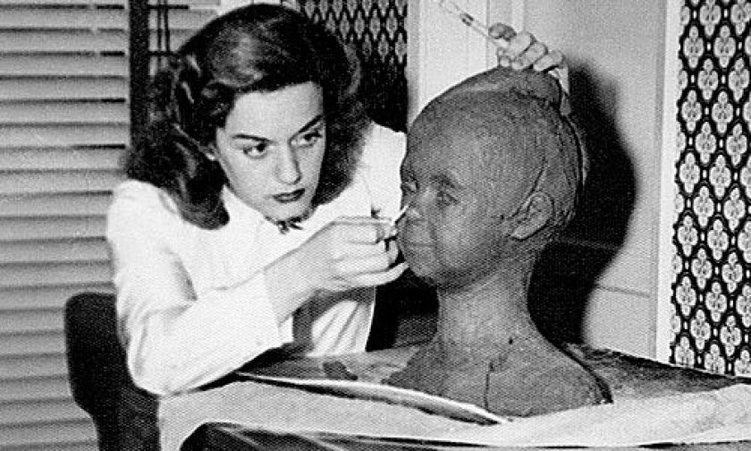

*Dina as an art school student before WWII.*  
*Source:* https://sfi.usc.edu/video/dina-gottliebova-babbitt-painting-auschwitz

[figure not shown]

*Collection of portraits of Roma people. Dina painted these watercolours in Auschwitz.*  
*Source:* http://www.gypsypedia.it/archives/porrajmos-lolocausto-del-popolo-rom/

[figure not shown]

*Detail of watercolours by Dina.*  
*Source:* http://www.gypsypedia.it/archives/porrajmos-lolocausto-del-popolo-rom/

## Digital archives and databases of names and fates of holocaust survivors

Every research project is like a big puzzle. You have to collect as many of those puzzle pieces as possible. Below you will find links to a couple of archives and databases containing information on Holocaust victims. You can use these to start your research. Follow the guidelines to find a specific person and their story.

### Digital archive – [US Holocaust Memorial Museum in Washington, D.C.](https://www.ushmm.org/)

The US Holocaust Memorial Museum’s [Database](https://www.ushmm.org/remember/resources-holocaust-survivors-victims/database-of-holocaust-survivor-and-victim-names) of Holocaust Survivor and Victim Names contains records of people persecuted during World War II under the Nazi regime, including Jews, Roma, Sinti, Poles (and other Slavic peoples), Soviet prisoners of war, persons with disabilities, political prisoners, trade union leaders, "subversive" artists, Catholic and Lutheran clergy who were seen as opponents of the regime, resisters, Jehovah's Witnesses, male homosexuals, and criminal offenders, among others. Learn more about the victims of the Holocaust and Nazi persecution.

**Task No. 1**  
Go to the database page:

- Type “Dina Gottlieb” or “Dina Babbitt” into the Search box.

Watch an interview with Dina [here](https://collections.ushmm.org/search/catalog/irn37287). The interview is moderated by David Rappaport, teacher of history at Palo Alto High School.

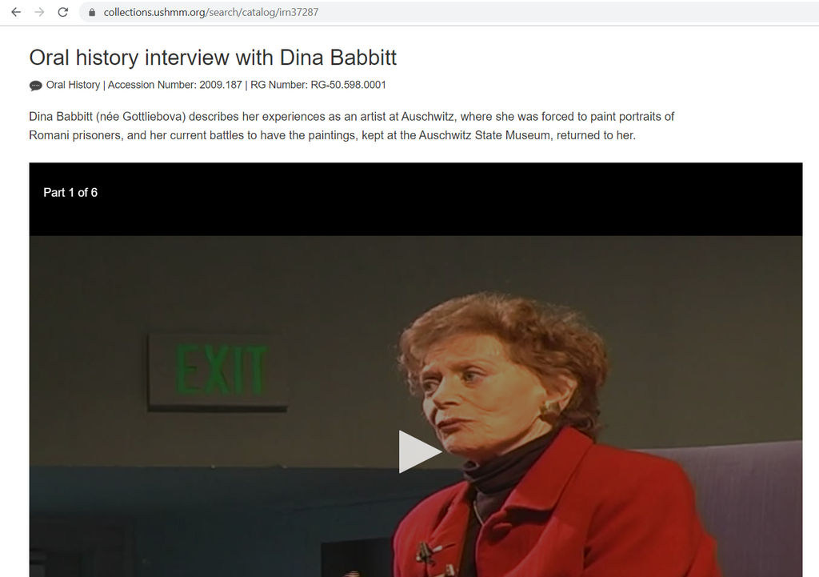

*Screenshot from the video testimony of Dina Gottlieb on the website of US Holocaust Memorial Museum in Washington.*  
*Source:* https://collections.ushmm.org/search/catalog/irn37287

**Task No. 2**  
Write a resume of her life story in 1,800 characters.

## Ethical dilemma and international trial

The story of Dina and her watercolour paintings started an international debate, as did the trial: Who is the owner of these artworks? What should be done in a situation like this? Should the Auschwitz museum respect Dina's rights as an artist, or is it more important to present her works to the public as historical artifacts? Or would it perhaps be more right to donate these artworks to the Roma community?

A quote from Czech researcher Judita Matyasova:

*“Dina´s story is a really good impulse for public and academic discussion. I think it is also an important part of the work of researchers: they have to think about different perspectives. What consequences might one decision cause to individuals or groups of people? Is it more important for the public interest? Or the interest of my person?”*

There are different perspectives on this debate:

- Read about the ethical dilemma in this [article](https://jhvonline.com/auschwitz-artifacts-an-ethical-dilemma-for-museums-p743-98.htm), written by Dinah Spritzer.
- Read more about activities of the American Congress [here](https://www.congress.gov/bill/106th-congress/house-concurrent-resolution/162/text).
- Read also another perspective, described in this [book](https://www.amazon.com/Watercolours-Story-Auschwitz-Lidia-Ostalowska-ebook/dp/B0756K3WQQ) by the famous Polish reporter, Lidia Ostalowska.

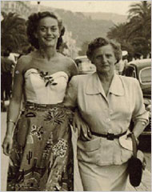

*Dina with her mother after the war.*  
*Source:* https://www.nytimes.com/2006/08/30/arts/design/30surv.html

[figure not shown]

*A Comic inspired by Dina´s story.*  
*Source:* https://babbittblog.com/2012/11/19/dina-babbitt-the-comic/

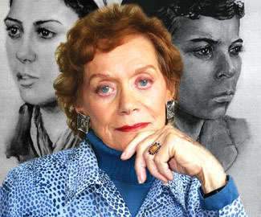

*Dina during the trial.*  
*Source:* https://www.nytimes.com/2006/08/30/arts/design/30surv.html

**Task No. 3: topic for discussion** Who is the owner of Dina´s artworks?  
Dina as the artist?  
OR  
The Auschwitz Museum?  
OR  
The Roma community?  
OR  
Doctor Josef Mengele´s relatives? (as he ordered these artworks)